# Appendix D4 - Correlation Analysis

Nathan Garcia-Diaz

2023-05-08

# 1 Packing Preparation and Importing Datasets

The following chunk preforms the following tasks:

```
* makes a list of packages names needed throughout the document
* loops through the list, and imports each of the packages
* imports the complete_tract_data, which contains the prevalence for a vierty of health conditions
```

```r
# the following code exhibits data exploration
package_lst = c("tidyverse", "gtsummary", "GGally", "broom", "bestglm", "caret", "webshot2", "here") # include other packages for logistic regression and data exploration
#lapply(package_lst, install.packages, character.only = TRUE)
lapply(package_lst, library, character.only = TRUE)

# importing data from counts and ratios data
complete_tract_data = read_csv(here("Data", "GenerateData", "complete_tract_data.csv"))

# defining clear ggplot background
theme_clear = theme(panel.grid.major = element_blank(), panel.grid.minor = element_blank(),
panel.background = element_blank(), axis.line = element_line(colour = "black"))
```

# 2 Correlation Analysis

## 2.1 Understanding Simple Linear Regression

Simple Linear Regression (SLR) allows to determine the relationship between two numeric variables. While multiple statistical methods can be used to determine the relationship between two numeric variables, I chose to use SLM because this method visualizes the relationship between two variables and interpretation of the results revolves around understanding three different values (i.e., correlation coefficient, R-squared, and p-value). Fundamentally, the SLM is the process of determining the linear equation for a scatter plot; scatter plot is the visual representation of plotting two numeric variables on a graph. The linear equation has been introduced throughout high school math courses, but for a brief reminder it is written as $y = mx + b$. Below is a list summarizing the components of the linear equation:

```
* X is the input value, and for the context of this analysis, it will always been the tract-level prevalence of adult cigarette smoking
* Y is the output value, and for the context of this analysis, will rotate between 5 different healthoutcomes
* M is the correlation coefficient, which is also known as the slope
* B is the y-intercept, or the point where the line meets the y-axis. Often times the y-intercept does not have real world interpretations, and therefore, it often ignored
```

When interpreting the results of a linear equation it is important to first examine the p-value. Previously, the p-value was described as the threshold determines the statistical relevance of a given variable. Using the same threshold of 0.05, the p-value preforms a similar function, which is to determine the validity of the SLR model. As a reminder, the p-value describes the the probability of observing test results which stem from an inherent relationship between variables rather than due to random chance.

The correlation coefficient, also known as the slope, determines the the amount of change along the Y-axis for every change along the X-axis. For example, *for every 1% increase in smoking prevalence in a census tract, there is an expect increase of X to the associated health outcome, where X represents the slope found in the equation.* Most importantly, there is a **large** limitations in results interpretation. Since census tract information inherently depicts population rather than individuals, the notion of Ecological Fallacy address. The Ecological Fallacy is the logical error made when applying the conclusions of aggregated data about a population towards an individual. For example, “if a specific neighborhood has a high crime rate, one might assume that any resident living in that area is more likely to commit a crime.” Therefore, I cannot say individuals who smoking are more likely to develop Chronic Obstructed Pulmonary Disease (COPD), however I can say that populations with higher smoking prevalence should expect an increase in COPD.

Lastly, the R-squared value is considered a metric to determine the effectiveness of a model in describing the data. The R-square can be interpreted as a percentage about how much of the data the model can account for. Thus, a value closer to 1, or 100%, would be most ideal, however it is often achievable.

## 2.2 Correlation Analysis

The following achieves the following goals:

```
(1) preforms linear regression across specified PLACES health variables
(2) creates individual graphs for the containing the scatter plot and simple linear model (SLM) equations
(3) create a larger ggplot object containing multiple scatter plots
```

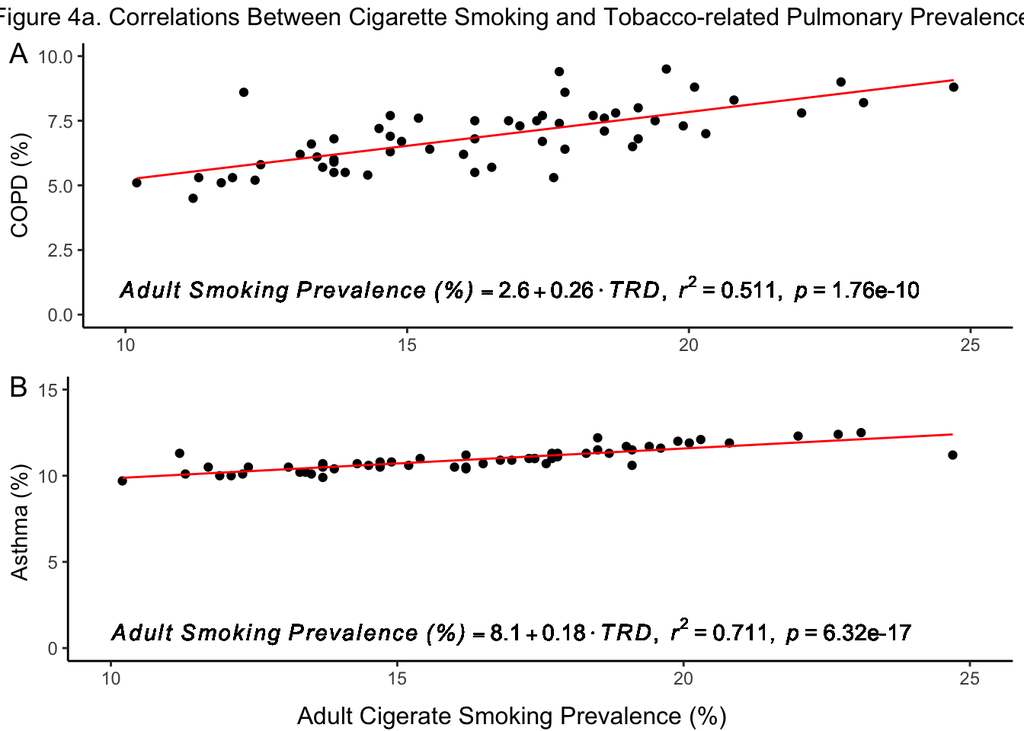

```r
# simplifying the data to include health data only
temp = complete_tract_data
temp = temp %>% select(matches("CrudePrev"))

###### making scatter plots with SLM equations
## create empty list for plots ##
plots <- vector('list', (length(colnames(temp)) - 1))

## creates loops for creating ggplot objects for desired variables ##
for (i in 2:ncol(temp)) {
  # idexes the ggplot object into the previously defined list
  plots[[i]] = local({
    # brings the i variable from outside the loop (this did not work without it)
    i = i
    # makes the linear equation to be fitted for each variable
    lm_eqn = function(temp){
    # define the equation being used
    m = lm(temp[[i]] ~ temp[[1]], temp);
    # the text in the final equation can be editing in the following line of code
    eq = substitute(italic(`Adult Smoking Prevalence (%)`) == a + b %.% italic(`TRD`)*","~~italic(r)^2~"="~r2*","~~italic("p")~"="~p,
         list(a = format(unname(coef(m)[1]), digits = 2),
              b = format(unname(coef(m)[2]), digits = 2),
             r2 = format(summary(m)$adj.r.squared, digits = 3),
              p = format(signif(as.numeric(glance(m)$p.value), 3))
             )
         )
    as.character(as.expression(eq));

   # print(plot(m)) -- produces diagnositc plots
}
    # create temp ggplot object that has the details that are shared amongst all graphs
    temp_plot <- ggplot(data = temp, aes(x = CSMOKING_CrudePrev, y = temp[[i]] )) +
      geom_point() + # creates scatter plot
      xlim(10,25) + # define x axis variables
      geom_smooth(method="lm", colour="red", size=0.5, se = FALSE) + # preforms SLM
      geom_text(x = 17, y = 1, label = lm_eqn(temp), parse = TRUE) + # adds the SLM equation
      theme_clear + # preferred theme for plot
      theme(axis.title.x = element_blank(), # remove the x-axis label from appearing in individual graphs
            axis.text.y=element_text(size=9) # changes the size of y-axis label
            )
}) }
 ## removes the empty positions in the list ##
plots = compact(plots)

 ## adds the additional lists for annotations for the rest of the plost ##
# COPD(%) annotations
plot_a = plots[[1]] +
  labs(y = "COPD (%)") + # creates the y-axis label
  ylim(0, 10) # defines y axis limits

# Asthma (%) annotations
plot_b = plots[[3]] +
  labs(y = "Asthma (%) ") +# creates the y-axis label
  ylim(0, 15) # defines y axis limits

# CHD (%) annotations
plot_c = plots[[2]] +
  labs(y = "CHD (%) ") + # creates the y-axis label
  ylim(0, 10) # defines y axis limits

# stroke (%) annotations
plot_d = plots[[4]] +
  labs(y = "Stroke (%) ") +# creates the y-axis label
  ylim(0, 5) # defines y axis limits

# depression (%) annotations
plot_e = plots[[5]] +
  labs(y = "Depression (%) ") + # creates the y-axis label
  ylim(0, 30) # defines y axis limits

 ## Combing Plots Together - PLOT 1##
fig4ab = ggpubr::ggarrange(plot_a, plot_b # defines the order of the plot — COPD and Asthma
                     ,labels = c("A", "B") # defines the labels
                     ,font.label = list(size=14, color = "black", face = 'plain') # defines label aesthetics
                     ,ncol = 1, nrow = 2) # defines the organization of graphs
# annotate plot 1
fig4ab = ggpubr::annotate_figure(p = fig4ab # defines the plot that will be organized
                ,top = "Figure 4a. Correlations Between Cigarette Smoking and Tobacco-related Pulmonary Prevalence" # the main title of the plot
                ,bottom = "Adult Cigerate Smoking Prevalence (%)")# defines the shared x-axis
fig4ab
```

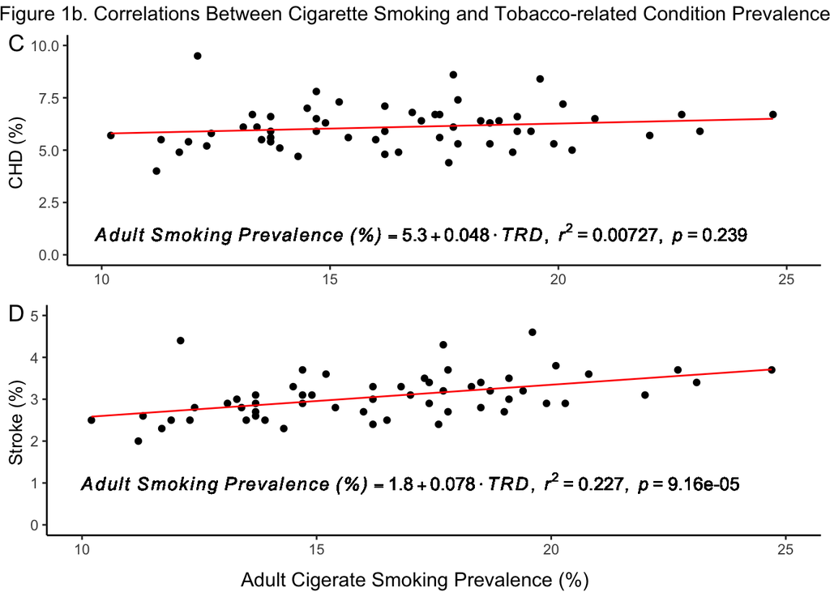

```r
ggsave(filename="fig4ab.png", plot = fig4ab)

 ## Combing Plots Together - PLOT 1##
fig4cd = ggpubr::ggarrange(plot_c, plot_d # defines the order of the plot - CHD and Stroke
                     ,labels = c("C", "D") # defines the labels
                     ,font.label = list(size=14, color = "black", face = 'plain') # defines label aesthetics
                     ,ncol = 1, nrow = 2) # defines the organization of graphs
fig4cd = ggpubr::annotate_figure(p = fig4cd # defines the plot that will be organized
                ,top = "Figure 1b. Correlations Between Cigarette Smoking and Tobacco-related Condition Prevalence" # the main title of the plot
                ,bottom = "Adult Cigerate Smoking Prevalence (%)")# defines the shared x-axis
fig4cd
```

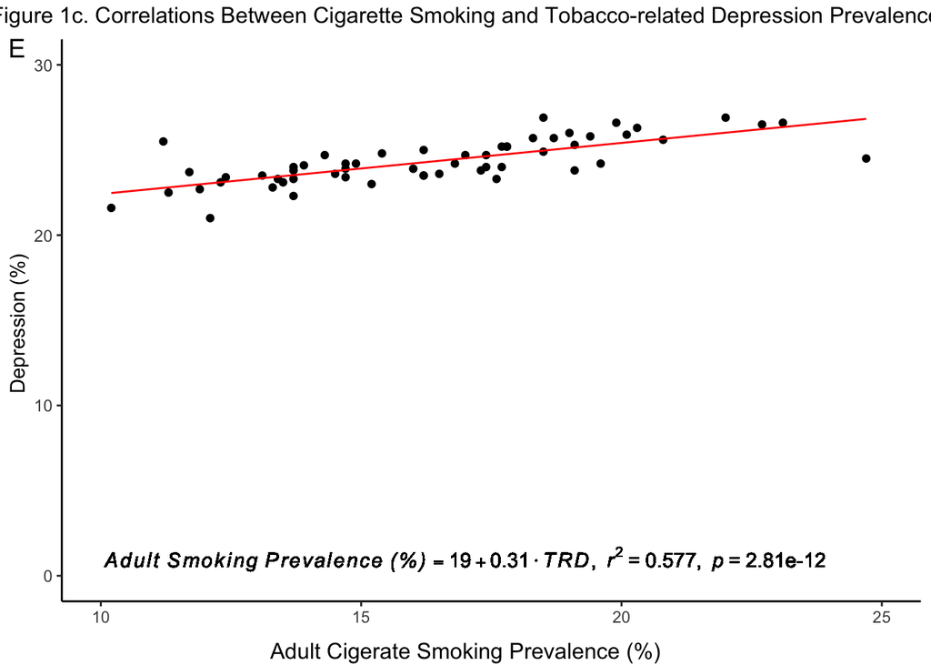

```r
ggsave(filename=here("Outputs", "fig4cd.png"), plot = fig4cd)

  ## Generating Plot ##
fig4e = ggpubr::ggarrange(plot_e # defines the order of the plot
                     ,labels = c("E") # defines the labels
                     ,font.label = list(size=14, color = "black", face = 'plain') # defines label aesthetics
                     ,ncol = 1, nrow = 1)
fig4e = ggpubr::annotate_figure(p = fig4e # defines the plot that will be organized
                ,top = "Figure 1c. Correlations Between Cigarette Smoking and Tobacco-related Depression Prevalence" # the main title of the plot
                ,bottom = "Adult Cigerate Smoking Prevalence (%)")# defines the shared x-axis
fig4e
```

```r
ggsave(filename=here("Outputs", "fig4e.png"), plot = fig4e)
```

## 2.3 Initial Investigation between Adult Cigarette Smoking Prevalence and Tobacco Retailer Density - Liner Regression

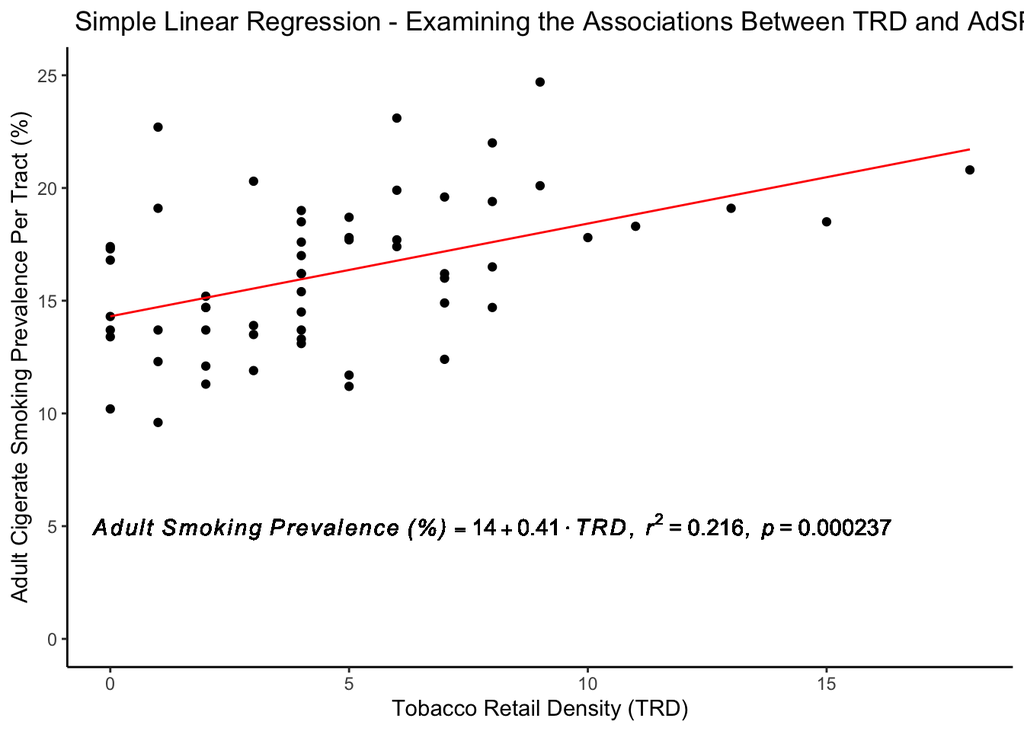

```r
# making temporary data set that only contains the primary input and output variables
temp = complete_tract_data
temp = temp %>%
  mutate("Adult Cigerate Smoking Prevalence Per Tract (%)" = CSMOKING_CrudePrev,
         "Tobacco Retailer Density" = trd_count) %>%
  select("Adult Cigerate Smoking Prevalence Per Tract (%)", "Tobacco Retailer Density")

# making a function that is able to spit out the equation for a SLM
lm_eqn = function(temp){
    # define the equation being used
    m = lm(temp$`Adult Cigerate Smoking Prevalence Per Tract (%)` ~ temp$`Tobacco Retailer Density`, temp);
    # the text in the final equation can be editing in the following line of code
    eq = substitute(italic(`Adult Smoking Prevalence (%)`) == a + b %.% italic(`TRD`)*","~~italic(r)^2~"="~r2*","~~italic("p")~"="~p,
         list(a = format(unname(coef(m)[1]), digits = 2),
              b = format(unname(coef(m)[2]), digits = 2),
             r2 = format(summary(m)$r.squared, digits = 3),
              p = format(signif(as.numeric(glance(m)$p.value), 3))
             )
         )
    as.character(as.expression(eq));
}

# defines the variable that are going to be used above
m = lm(temp$`Adult Cigerate Smoking Prevalence Per Tract (%)` ~ temp$`Tobacco Retailer Density`, temp)
adj.r.squared = glance(m)$adj.r.squared
p.value = glance(m)$p.value

# print diagnostic plots
# plot(m)

# making a scatter plot with the primary variables and the equation
plt = ggplot(temp, aes(x = temp$`Tobacco Retailer Density`, y = temp$`Adult Cigerate Smoking Prevalence Per Tract (%)`)) +
  geom_point() +
  geom_smooth(method="lm", colour="red", size=0.5, se = FALSE) +
  geom_text(x = 8, y = 5, label = lm_eqn(temp), parse = TRUE) +
  labs(title = " Simple Linear Regression - Examining the Associations Between TRD and AdSP") +
  ylab("Adult Cigerate Smoking Prevalence Per Tract (%)") +
  xlab("Tobacco Retail Density (TRD)") +
  ylim(0,25) +
  theme_clear

plt
```

```r
ggsave(filename=here("Outputs", "Figure5.png"), plot = plt)
```

While a non-linear model could have been fitted because I am looking for a baseline associated with easy interpretation, a SLR model was choose to create an initial exploration between the primary variables. Since the same regression is being applied, the interpretation of the equation is the same. *For each additional retailer within a census tract, there is an expect increase of 0.41% of a tract’s adult cigarette smoking prevalence*.